# Interactive Iris

Cees Roele

2023-05-04

# Predicting Iris Species

*Interactive Iris* is an online shiny application which allows flower-lovers & others to find the most likely species of iris by simply setting sepal/petal and length/width parameters using sliders. As there still may be some uncertainty, in addition to the most likely name, a barchart is displayed showing the probability of different species for the selected parameters.

Besides displaying results in the *Result* tab, you will find a visual represention of the model in the *Decision Tree* tab. If in doubt, more information on the application and how to use it is available under the *Documentation* tab.

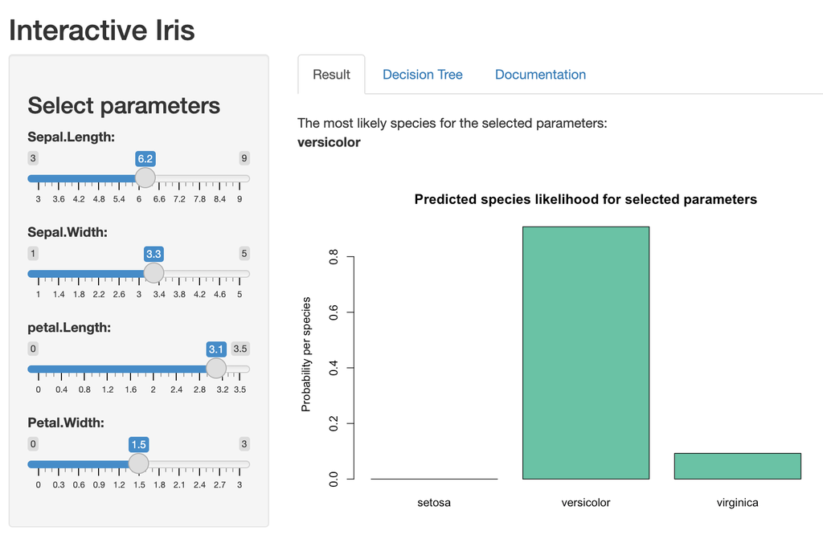

# Data

To make predictions a model is created using the famous *iris* dataset which is available by default in the R programmming language environment.

In this dataset three species of iris are distinguished. They are mentioned below with the number of samples in the dataset for each of them.

```
##
##     setosa versicolor  virginica
##         50         50         50
```

For all samples four measurements were taken. These observations have the following characteristics:

```
##   Sepal.Length    Sepal.Width     Petal.Length    Petal.Width
##  Min.   :4.300   Min.   :2.000   Min.   :1.000   Min.   :0.100
##  Median :5.800   Median :3.000   Median :4.350   Median :1.300
##  Max.   :7.900   Max.   :4.400   Max.   :6.900   Max.   :2.500
```

# Decision Tree Model

The state of the art model used for predicting iris species was created using the advanced technology of the R language with a simple statement operating on the data:

```r
model <- rpart(Species~., data=iris)
```

With another simple instruction the model can be represented visually.

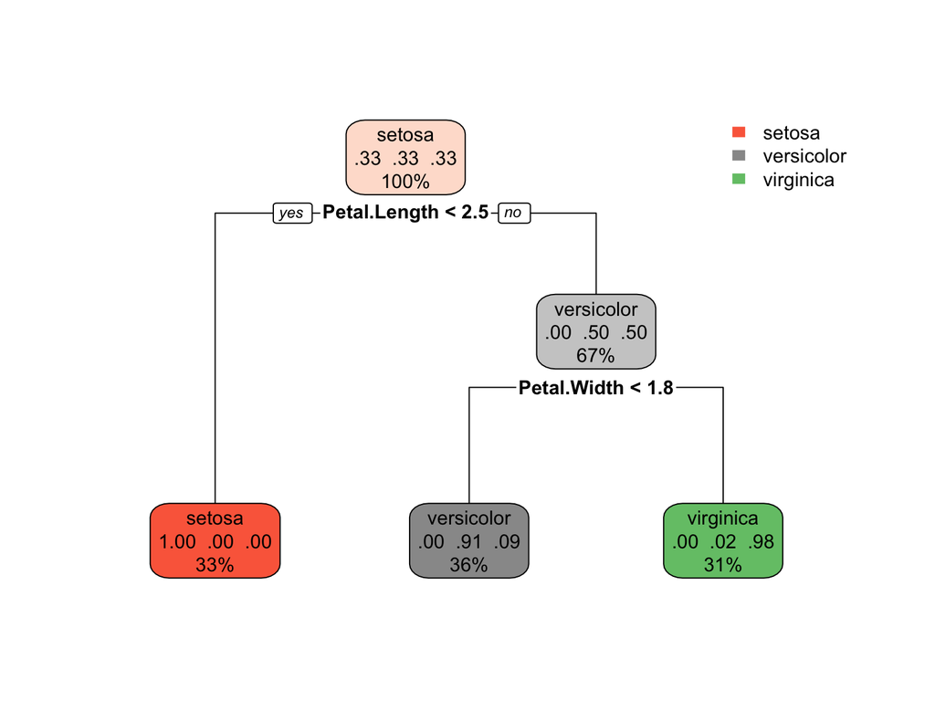

```r
rpart.plot(model)
```

For your convenience, the above diagram is always available at your fingertips in the *Decision Tree* tab of the *Interactive Iris* application.

# Understanding outcome

After selecting the *sepal* and *petal* parameters using the sliders, the *Result* tab will display the most likely iris species for those values based on a prediction by its model.

Let’s see what happens under the hood. Let’s assume the following sepal and petal values, which in *Interactive Iris* you can set using sliders.

```r
my_observations <- data.frame(Sepal.Length=5.8, Sepal.Width=3.0, Petal.Length=2.8, Petal.Width=1.2)
```

The numerical outcome of the prediction using the *Interactive Iris* model is:

```r
prediction <- predict(model, my_observations)
prediction
```

```
##   setosa versicolor  virginica
## 1      0  0.9074074 0.09259259
```

As you see, this prediction result does not give a single species as outcome, but a likelihood for each species. For your convenience the species with the highest score is shown in the result tab.

But as you also may want to understand uncertainty in the outcome, where several species may actually be a good outcome, an easy to read barchart will show what the probabilities per species are.

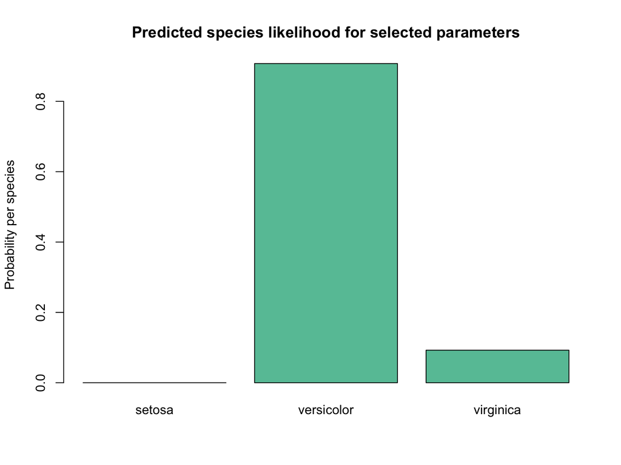

We see in this example that *versicolor* is most likely, but that there is also a chance that *virginica* is the correct species for these observations.

### That’s all! Enjoy *Interactive Iris*!